# FordGoBikes Analysis in the Bay Area

## January 2019 - December 2019

### By Tash

## Investigation Overview

> Formerly known as Ford GoBikes, renamed Lyft Bikes is a regional public bicycle sharing system in the San Francisco Bay Area, California. In this investigation, I've looked at the bike ride trends and biker type of the bay Ford GoBike Share system. The main focus was on biking duration, the time (weekday, hour), and the bike types.

## Dataset Overview

> This overivew explores the Ford GoBike's which is combined with the Baywheels trip data for public containing bike rides in the Bay Area from January 2019 to December 2019.

## Ford GoBike System Monthly Usage in 2019

> As per the Ford GoBike System in 2019, July is the most popular month for using the Ford GoBike System with over 250,000 number of bike trips. Followed by March and October.

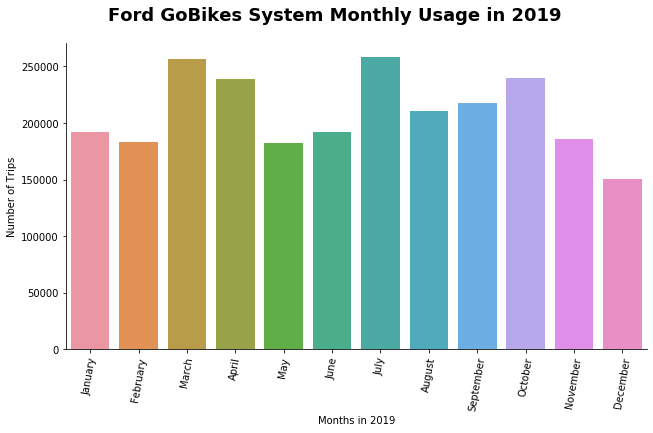

```python
#Display mFord GoBikes System Monthly Usage in 2019
graph = sb.catplot(data = df_master_cleaned, x = 'start_time_month',
                   kind = 'count', aspect = 1.8);
graph.set_axis_labels('Months in 2019','Number of Trips'),
graph.fig.suptitle('Ford GoBikes System Monthly Usage in 2019',
                   y = 1.07, fontsize = 18, fontweight = 'bold');
graph.set_xticklabels(rotation=80);
```

## Ford GoBike System Usage by Hour

> The Ford GoBike System Usage in hours was popular between the hours of 8-9 am and 5-6 pm.

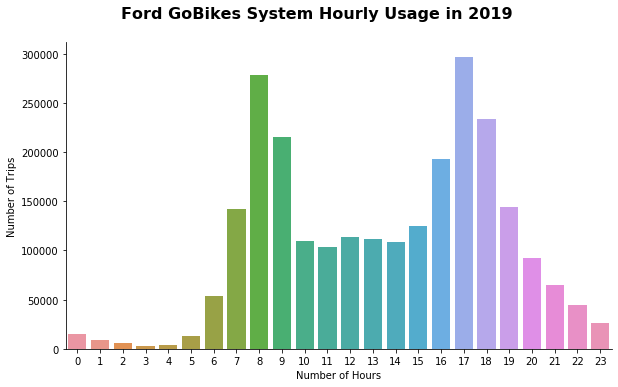

```python
# Ford GoBike System Hourly Usage in 2019
graph = sb.catplot(data = df_master_cleaned, x='start_time_hour', kind='count', aspect = 1.7)
graph.set_axis_labels('Number of Hours', 'Number of Trips')
graph.fig.suptitle('Ford GoBikes System Hourly Usage in 2019',
                   y=1.07, fontsize=16, fontweight='bold');
```

## Ford GoBike System Trends by User Type

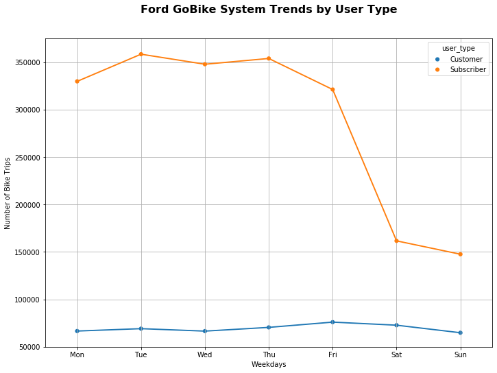

```python
# Compare the Customer and Subscriber Trends over the week
plt.figure(figsize=[ 11.69, 8.27]);
df_master_cleaned_user_week = df_master_cleaned.groupby(['start_time_weekday', 'user_type']).size().reset_index()
weekday = ['Mon', 'Tue', 'Wed', 'Thu', 'Fri', 'Sat', 'Sun']
ax = sb.pointplot(data=df_master_cleaned_user_week, x='start_time_weekday', y=0, hue = 'user_type', scale=.7, order = weekday);
plt.title('Ford GoBike System Trends by User Type', y=1.07, fontsize=16, fontweight='bold')
plt.xlabel('Weekdays')
plt.ylabel('Number of Bike Trips');
plt.grid()
```

## Ford GoBike System Monthly Usage Per User Type

> In 2019, the Ford GoBike Monthly Usage per User Type. There are two types of users who use the Ford GoBike which is between Customer and Subscriber.

> Customers saw an increase of usage in December while Subscribers would frequently use the the Ford GoBike system in March, July and April. While the Monthly usage for Subscribers would decrease in December.

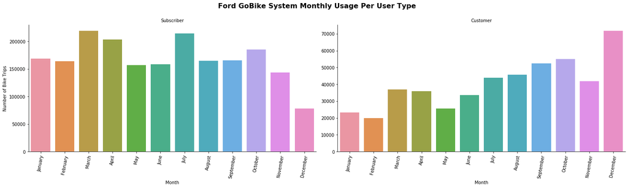

```python
# Monthly usage by user type
graph = sb.catplot(data=df_master_cleaned, x='start_time_month', col="user_type", kind='count', sharey = False, height=5, aspect=2);
graph.set_axis_labels("Month", "Number of Bike Trips")
graph.set_titles("{col_name}")
graph.fig.suptitle('Ford GoBike System Monthly Usage Per User Type', y=1.07, fontsize=16, fontweight='bold');
graph.set_xticklabels(rotation=80);
```

## References

How To Combine Multiple CSV Files In Python: https://sempioneer.com/python-for-seo/how-to-combine-multiple-csv-files-in-python/ FordGoBike Data Set: https://www.lyft.com/bikes/bay-wheels/system-data Github: https://github.com/ijdev/Ford-GoBike-System-Data---Data-Analysis/blob/master/exploration_template.ipynb, Github: https://github.com/satyarajreddy/Udacity-Data-Visualization/blob/master/Visualize_Data.ipynb Github: https://gist.github.com/rochacbruno/2883505 Github: https://github.com/chelseymarie6/Communicate-Data-Findings Github: https://github.com/rishusingh121/fordgobike/blob/master/slide_deck_template.ipynb Keggle: https://www.kaggle.com/chirag02/ford-gobike-data-analysis seaborn catplot: https://seaborn.pydata.org/generated/seaborn.catplot.html matplotlib Documentation: https://matplotlib.org/api/_as_gen/matplotlib.pyplot.hist.html